# BA636_Project_Hien Do & Khanh Dang

```r
knitr::opts_chunk$set(echo = TRUE)
library(dplyr)
library(tidyverse)
library(here)
library(ggmosaic)
library(jwutil)
library(kableExtra)
library(readxl)
library(ggplot2)
library(forecast)
library(igraph)
library(treemap)
library(ggmap)
library(mosaic)
library(gplots)
library(reshape)
library(RColorBrewer)
library(GGally)
library(scales)
library(MASS)
library(gains)
library(caret)
library(kableExtra)
library(arsenal)
library(leaps)
library(e1071)
library(plotrix)
library(readr)
library(ggplot2)
library(tidyr)
library(tidyverse)
library(dplyr)
library(forecast)
library(kableExtra)
library(effects)
library(lmtest)
library(car)
library(broom)
library(plotrix)
library(caret)
library(gains)
library(FNN)
library(e1071)
bank.df<-readr::read_csv('../../Selected dataset/bank-additional-full.csv')
data.dictionary<-read_xlsx('../Data_Dictionary.xlsx')
```

### **Data Dictionary**

```r
data.dictionary%>%kable(caption = "Table: Data Dictionary of Term Deposit File")%>%kableExtra::kable_styling(bootstrap_options = "striped")
```

Table: Data Dictionary of Term Deposit File

| Column Name | Position | Data Type | Description |
| --- | --- | --- | --- |
| Age | 1 | Numeric | Age of customer |
| Job | 2 | Categorical | Type of job, including: admin, blue-collar, entrepreuneur, housemaid, management, retired, self-employed, services, student, technician, unemployment, unknown |
| Marital | 3 | Categorical | Marital status of customer including: divorced, married, single, unknown |
| Education | 4 | Categorical | Education level of customer including: basic.4y, basic.6y, basic.9y, high school, illiterate, professional.course, university.degree, unknown |
| Default | 5 | Categorical | Whether the customer has credit default or not (no, yes and unkown) |
| Housing | 6 | Categorical | Whether the customer has housing loan or not (no, yes and unknown) |
| Loan | 7 | Categorical | Whether the customer has personal loan or not (no, yes and unknwon) |
| Contact | 8 | Categorical | Contact communication type including cellular, telephone |
| Month | 9 | Categorical | Last contact month of year (from jan to dec) |
| Day_of_week | 10 | Categorical | Last contact day of week (mon, tue, wed, thu, fri) |
| Duration | 11 | Numeric | Last contact duration, in seconds |
| Campiagn | 12 | Numeric | Number of contact performed during this campaign and for this client |
| Pdays | 13 | Numeric | Number of days that passed by after the clients was last contacted from a previous campaign (numeric 999 means that clients was not contacted previously) |
| Previous | 14 | Numeric | Number of contact performed before this campaign and for this client |
| Poutcome | 15 | Categorical | Outcome of the previous marketing campaign (“failure”, “nonexistent”, “success”) |
| Emp.var.rate | 16 | Numeric | Employment variation rate - quaterly indcator |
| Cons.price.idx | 17 | Numeric | Consumer price index - monthly indicator |
| Cons.cof.idx | 18 | Numeric | Consumer confidence index - monthly indicator |
| Euribor3m | 19 | Numeric | Euribor 3 month rate - daily indicator |
| Nr.employed | 20 | Numeric | Number of employees - quarterly indicator |
| y | 21 | Binary | Whether the client has subcribed a term deposit or not? |

### **1. Looking at the data**

```r
kbl(dim(bank.df))
```

| x |
| --- |
| 41188 |
| 21 |

```r
head(bank.df, 10)%>%kable(caption = "Table: Ten fisrt rows of bank data")%>%kableExtra::kable_styling(bootstrap_options = "striped")
```

Table: Ten fisrt rows of bank data

| age | job | marital | education | default | housing | loan | contact | month | day_of_week | duration | campaign | pdays | previous | poutcome | emp.var.rate | cons.price.idx | cons.conf.idx | euribor3m | nr.employed | y |
| --- | --- | --- | --- | --- | --- | --- | --- | --- | --- | --- | --- | --- | --- | --- | --- | --- | --- | --- | --- | --- |
| 56 | housemaid | married | basic.4y | no | no | no | telephone | may | mon | 261 | 1 | 999 | 0 | nonexistent | 1.1 | 93.994 | -36.4 | 4.857 | 5191 | no |
| 57 | services | married | high.school | unknown | no | no | telephone | may | mon | 149 | 1 | 999 | 0 | nonexistent | 1.1 | 93.994 | -36.4 | 4.857 | 5191 | no |
| 37 | services | married | high.school | no | yes | no | telephone | may | mon | 226 | 1 | 999 | 0 | nonexistent | 1.1 | 93.994 | -36.4 | 4.857 | 5191 | no |
| 40 | admin. | married | basic.6y | no | no | no | telephone | may | mon | 151 | 1 | 999 | 0 | nonexistent | 1.1 | 93.994 | -36.4 | 4.857 | 5191 | no |
| 56 | services | married | high.school | no | no | yes | telephone | may | mon | 307 | 1 | 999 | 0 | nonexistent | 1.1 | 93.994 | -36.4 | 4.857 | 5191 | no |
| 45 | services | married | basic.9y | unknown | no | no | telephone | may | mon | 198 | 1 | 999 | 0 | nonexistent | 1.1 | 93.994 | -36.4 | 4.857 | 5191 | no |
| 59 | admin. | married | professional.course | no | no | no | telephone | may | mon | 139 | 1 | 999 | 0 | nonexistent | 1.1 | 93.994 | -36.4 | 4.857 | 5191 | no |
| 41 | blue-collar | married | unknown | unknown | no | no | telephone | may | mon | 217 | 1 | 999 | 0 | nonexistent | 1.1 | 93.994 | -36.4 | 4.857 | 5191 | no |
| 24 | technician | single | professional.course | no | yes | no | telephone | may | mon | 380 | 1 | 999 | 0 | nonexistent | 1.1 | 93.994 | -36.4 | 4.857 | 5191 | no |
| 25 | services | single | high.school | no | yes | no | telephone | may | mon | 50 | 1 | 999 | 0 | nonexistent | 1.1 | 93.994 | -36.4 | 4.857 | 5191 | no |

```r
kbl(str(bank.df))%>%
  kable_styling()
```

```
## tibble [41,188 x 21] (S3: spec_tbl_df/tbl_df/tbl/data.frame)
##  $ age           : num [1:41188] 56 57 37 40 56 45 59 41 24 25 ...
##  $ job           : chr [1:41188] "housemaid" "services" "services" "admin." ...
##  $ marital       : chr [1:41188] "married" "married" "married" "married" ...
##  $ education     : chr [1:41188] "basic.4y" "high.school" "high.school" "basic.6y" ...
##  $ default       : chr [1:41188] "no" "unknown" "no" "no" ...
##  $ housing       : chr [1:41188] "no" "no" "yes" "no" ...
##  $ loan          : chr [1:41188] "no" "no" "no" "no" ...
##  $ contact       : chr [1:41188] "telephone" "telephone" "telephone" "telephone" ...
##  $ month         : chr [1:41188] "may" "may" "may" "may" ...
##  $ day_of_week   : chr [1:41188] "mon" "mon" "mon" "mon" ...
##  $ duration      : num [1:41188] 261 149 226 151 307 198 139 217 380 50 ...
##  $ campaign      : num [1:41188] 1 1 1 1 1 1 1 1 1 1 ...
##  $ pdays         : num [1:41188] 999 999 999 999 999 999 999 999 999 999 ...
##  $ previous      : num [1:41188] 0 0 0 0 0 0 0 0 0 0 ...
##  $ poutcome      : chr [1:41188] "nonexistent" "nonexistent" "nonexistent" "nonexistent" ...
##  $ emp.var.rate  : num [1:41188] 1.1 1.1 1.1 1.1 1.1 1.1 1.1 1.1 1.1 1.1 ...
##  $ cons.price.idx: num [1:41188] 94 94 94 94 94 ...
##  $ cons.conf.idx : num [1:41188] -36.4 -36.4 -36.4 -36.4 -36.4 -36.4 -36.4 -36.4 -36.4 -36.4 ...
##  $ euribor3m     : num [1:41188] 4.86 4.86 4.86 4.86 4.86 ...
##  $ nr.employed   : num [1:41188] 5191 5191 5191 5191 5191 ...
##  $ y             : chr [1:41188] "no" "no" "no" "no" ...
##  - attr(*, "spec")=
##   .. cols(
##   ..   age = col_double(),
##   ..   job = col_character(),
##   ..   marital = col_character(),
##   ..   education = col_character(),
##   ..   default = col_character(),
##   ..   housing = col_character(),
##   ..   loan = col_character(),
##   ..   contact = col_character(),
##   ..   month = col_character(),
##   ..   day_of_week = col_character(),
##   ..   duration = col_double(),
##   ..   campaign = col_double(),
##   ..   pdays = col_double(),
##   ..   previous = col_double(),
##   ..   poutcome = col_character(),
##   ..   emp.var.rate = col_double(),
##   ..   cons.price.idx = col_double(),
##   ..   cons.conf.idx = col_double(),
##   ..   euribor3m = col_double(),
##   ..   nr.employed = col_double(),
##   ..   y = col_character()
##   .. )
```

### **2.Summary Statistics of numerical variables and missing values**

```r
numerical.variables<-c(1,11,12,13,14,16,17,18,19,20)
table.summary<-data.frame(mean=sapply(bank.df[,numerical.variables], mean),sd=sapply(bank.df[,numerical.variables], sd), min=sapply(bank.df[,numerical.variables],min), max=sapply(bank.df[,numerical.variables],max), median=sapply(bank.df[,numerical.variables],median))
table.missing<-data.frame(miss.val=sapply(bank.df, function(x)
  sum(length(which(is.na(x))))))
table.summary%>%kable(caption = "Table: Summary Statistic of all numerical variables")%>%kableExtra::kable_styling(bootstrap_options = "striped")
```

Table: Summary Statistic of all numerical variables

|  | mean | sd | min | max | median |
| --- | --- | --- | --- | --- | --- |
| age | 40.0240604 | 10.4212500 | 17.000 | 98.000 | 38.000 |
| duration | 258.2850102 | 259.2792488 | 0.000 | 4918.000 | 180.000 |
| campaign | 2.5675925 | 2.7700135 | 1.000 | 56.000 | 2.000 |
| pdays | 962.4754540 | 186.9109073 | 0.000 | 999.000 | 999.000 |
| previous | 0.1729630 | 0.4949011 | 0.000 | 7.000 | 0.000 |
| emp.var.rate | 0.0818855 | 1.5709597 | -3.400 | 1.400 | 1.100 |
| cons.price.idx | 93.5756644 | 0.5788400 | 92.201 | 94.767 | 93.749 |
| cons.conf.idx | -40.5026003 | 4.6281979 | -50.800 | -26.900 | -41.800 |
| euribor3m | 3.6212908 | 1.7344474 | 0.634 | 5.045 | 4.857 |
| nr.employed | 5167.0359109 | 72.2515277 | 4963.600 | 5228.100 | 5191.000 |

```r
table.missing%>%kable(caption = "Table: Number of missing values")%>%kableExtra::kable_styling(bootstrap_options = "striped")
```

Table: Number of missing values

|  | miss.val |
| --- | --- |
| age | 0 |
| job | 0 |
| marital | 0 |
| education | 0 |
| default | 0 |
| housing | 0 |
| loan | 0 |
| contact | 0 |
| month | 0 |
| day_of_week | 0 |
| duration | 0 |
| campaign | 0 |
| pdays | 0 |
| previous | 0 |
| poutcome | 0 |
| emp.var.rate | 0 |
| cons.price.idx | 0 |
| cons.conf.idx | 0 |
| euribor3m | 0 |
| nr.employed | 0 |
| y | 0 |

### **3. Understanding data by visualization**

*Categorized variables*

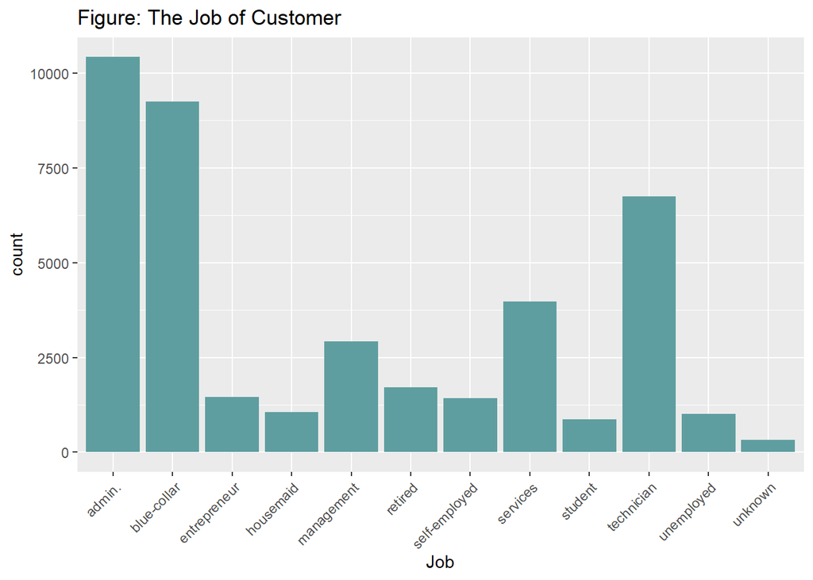

```r
par(mfrow=c(1,3))
ggplot(bank.df, aes(x=bank.df$job))+
  geom_histogram(fill = "cadetblue", stat = "count")+
  ggtitle("Figure: The Job of Customer")+
  labs(x = "Job")+
  theme(axis.text.x=element_text(angle=45, hjust =1))
```

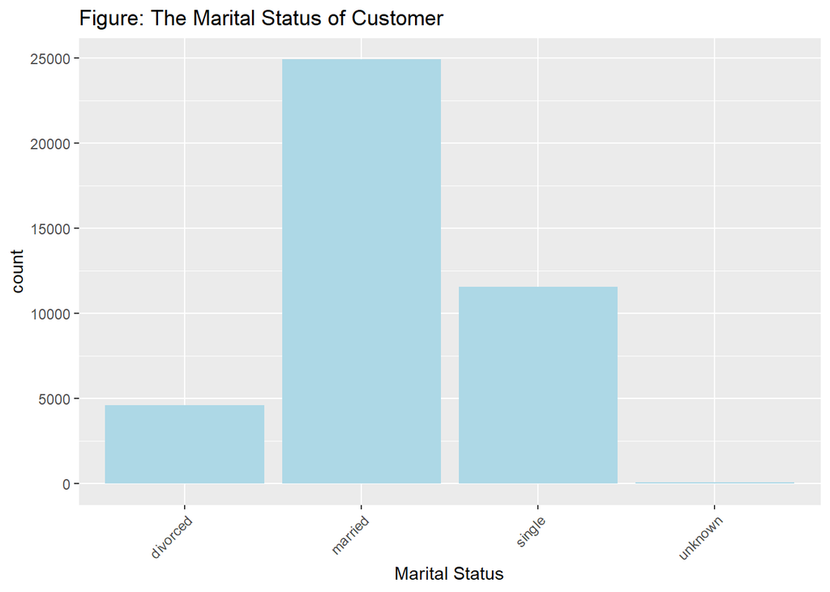

```r
ggplot(bank.df, aes(x=bank.df$marital))+
  geom_histogram(fill = "lightblue", stat = "count")+
  ggtitle("Figure: The Marital Status of Customer")+
  labs(x = "Marital Status")+
  theme(axis.text.x=element_text(angle=45, hjust =1))
```

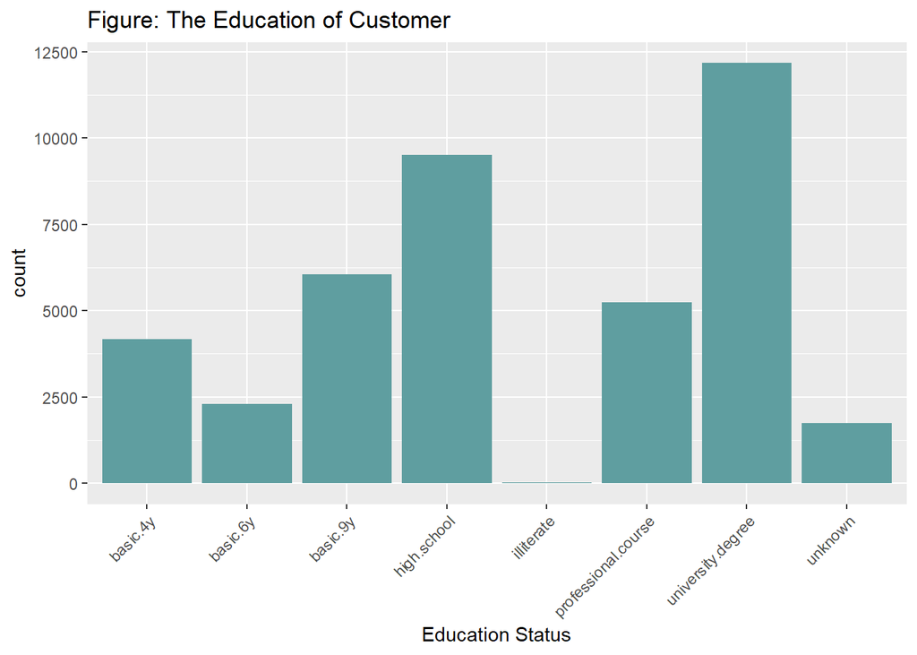

```r
ggplot(bank.df, aes(x=bank.df$education))+
  geom_histogram(fill = "cadetblue", stat = "count")+
  ggtitle("Figure: The Education of Customer")+
  labs(x = "Education Status")+
  theme(axis.text.x=element_text(angle=45, hjust =1))
```

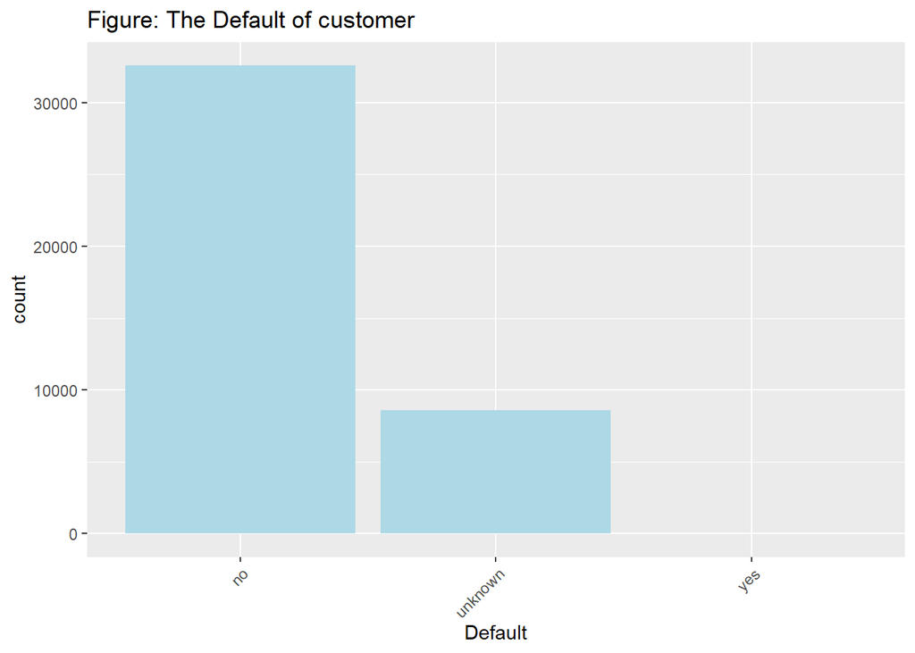

```r
par(mfrow=c(1,2))
ggplot(bank.df, aes(x=bank.df$default))+
  geom_histogram(fill = "lightblue", stat = "count")+
  ggtitle("Figure: The Default of customer")+
  labs(x = "Default")+
  theme(axis.text.x=element_text(angle=45, hjust =1))
```

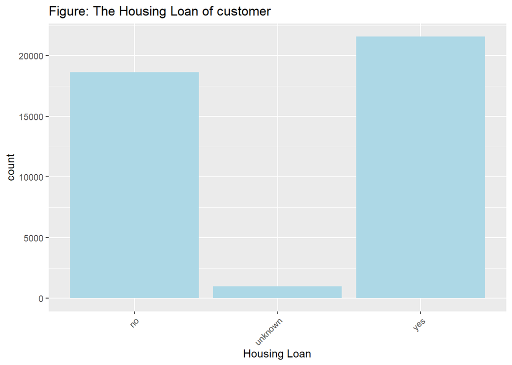

```r
ggplot(bank.df, aes(x=bank.df$housing))+
  geom_histogram(fill = "lightblue", stat = "count")+
  ggtitle("Figure: The Housing Loan of customer")+
  labs(x = "Housing Loan")+
  theme(axis.text.x=element_text(angle=45, hjust =1))
```

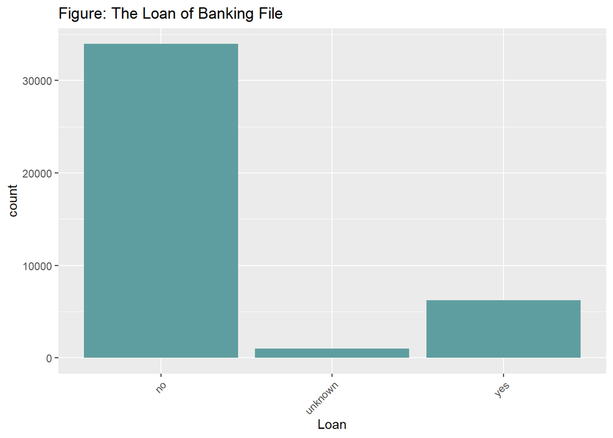

```r
par(mfrow=c(1,3))
ggplot(bank.df, aes(x=bank.df$loan))+
  geom_histogram(fill = "cadetblue", stat = "count")+
  ggtitle("Figure: The Loan of Banking File")+
  labs(x = "Loan")+
  theme(axis.text.x=element_text(angle=45, hjust =1))
```

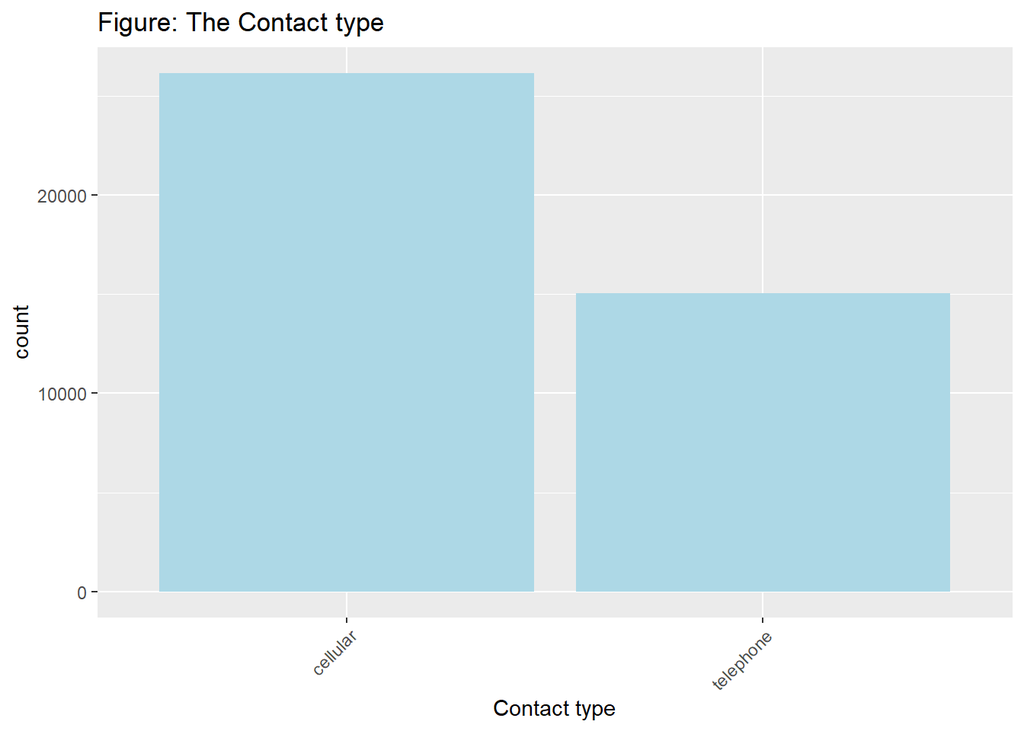

```r
ggplot(bank.df, aes(x=bank.df$contact))+
  geom_histogram(fill = "lightblue", stat = "count")+
  ggtitle("Figure: The Contact type")+
  labs(x = "Contact type")+
  theme(axis.text.x=element_text(angle=45, hjust =1))
```

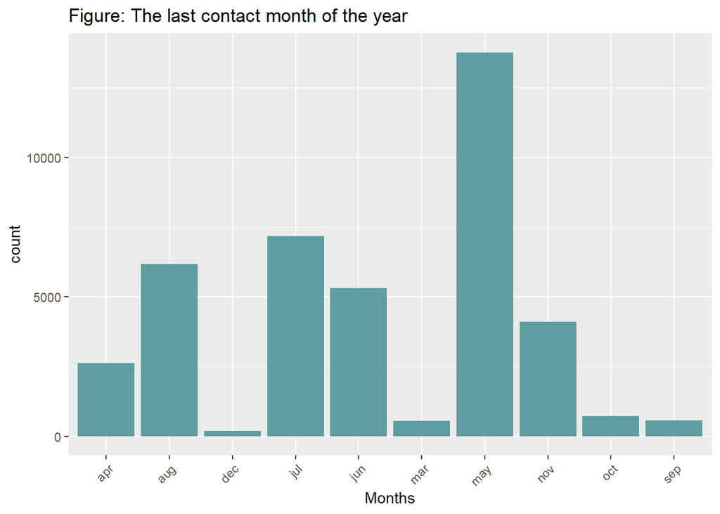

```r
ggplot(bank.df, aes(x=bank.df$month))+
  geom_histogram(fill = "cadetblue", stat = "count")+
  ggtitle("Figure: The last contact month of the year")+
  labs(x = "Months")+
  theme(axis.text.x=element_text(angle=45, hjust =1))
```

*Numeric Variables*

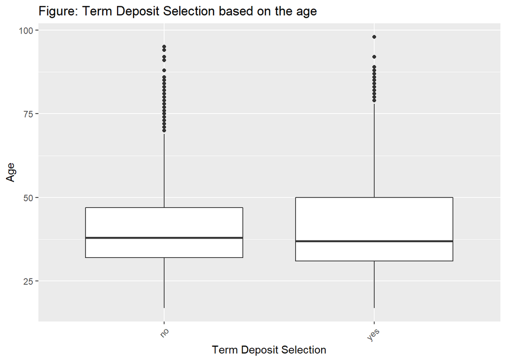

```r
ggplot(bank.df, aes(y, age))+
  geom_boxplot() +
  ggtitle("Figure: Term Deposit Selection based on the age")+
  labs(x = "Term Deposit Selection", y="Age")+
  theme(axis.text.x=element_text(angle=45, hjust =1))
```

**The relation of each predictor on the other**

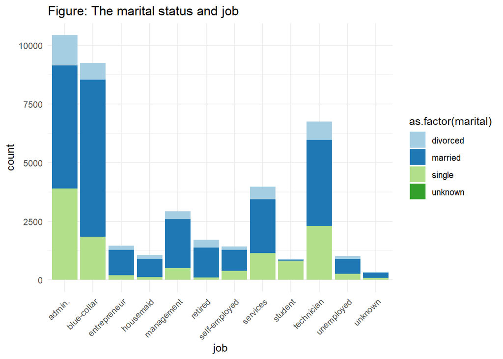

```r
ggplot(data=bank.df)+geom_bar(aes(x=job, fill= as.factor(marital)))+
  theme_minimal()+
  ggtitle(label = "Figure: The marital status and job")+
  scale_fill_brewer(palette="Paired")+
   theme(axis.text.x=element_text(angle=45, hjust =1))
```

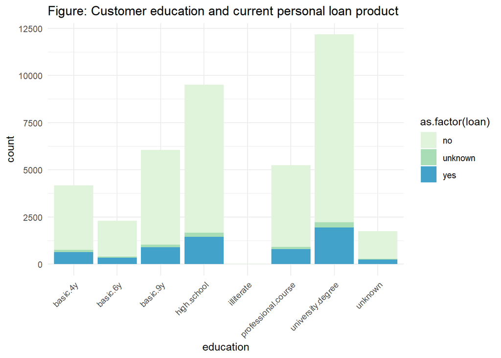

```r
ggplot(data=bank.df)+geom_bar(aes(x=education, fill= as.factor(loan)))+
  theme_minimal()+
  ggtitle(label = "Figure: Customer education and current personal loan product")+
  scale_fill_brewer(palette="GnBu")+
  theme(axis.text.x=element_text(angle=45, hjust =1))
```

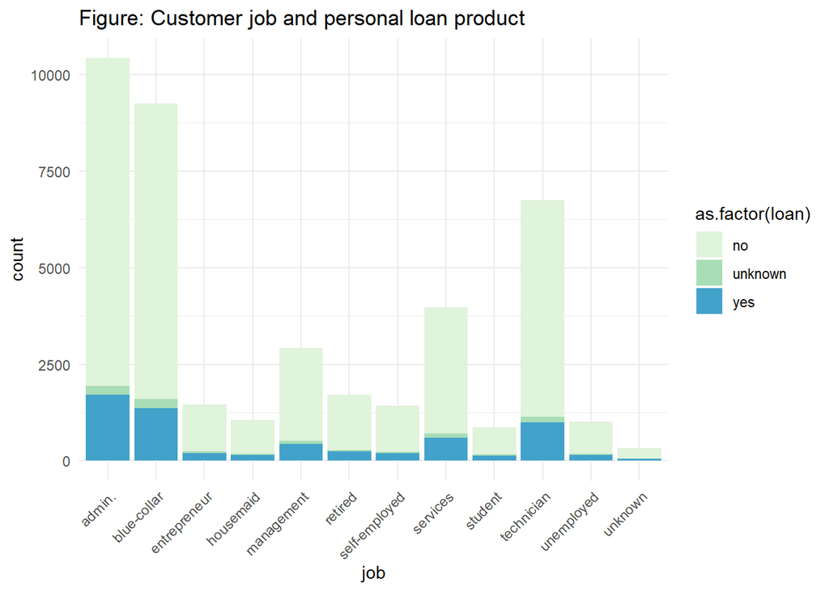

```r
ggplot(data=bank.df)+geom_bar(aes(x=job, fill= as.factor(loan)))+
  theme_minimal()+
  ggtitle(label = "Figure: Customer job and personal loan product")+
  scale_fill_brewer(palette="GnBu")+
  theme(axis.text.x=element_text(angle=45, hjust =1))
```

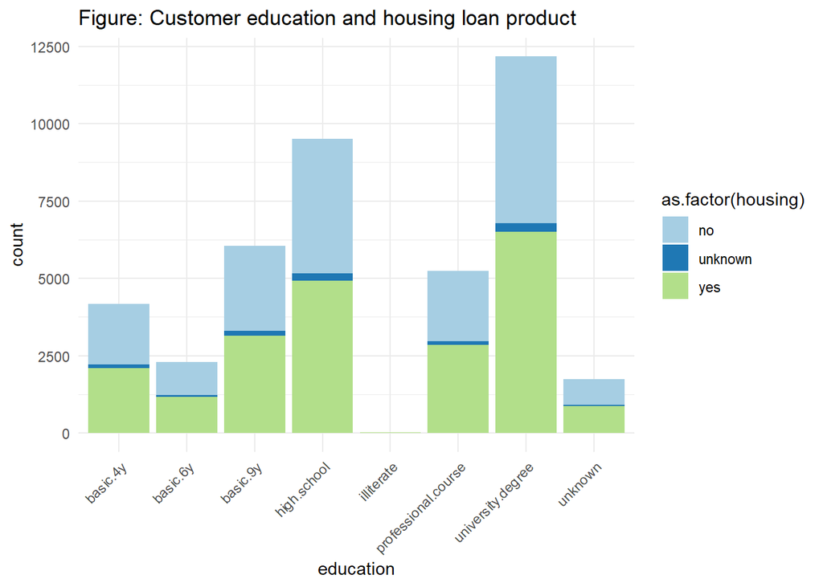

```r
ggplot(data=bank.df)+geom_bar(aes(x=education, fill= as.factor(housing)))+
  ggtitle(label = "Figure: Customer education and housing loan product")+
  theme_minimal()+
  scale_fill_brewer(palette="Paired")+
  theme(axis.text.x=element_text(angle=45, hjust =1))
```

**Bar charts and distribution plots to summarize data**

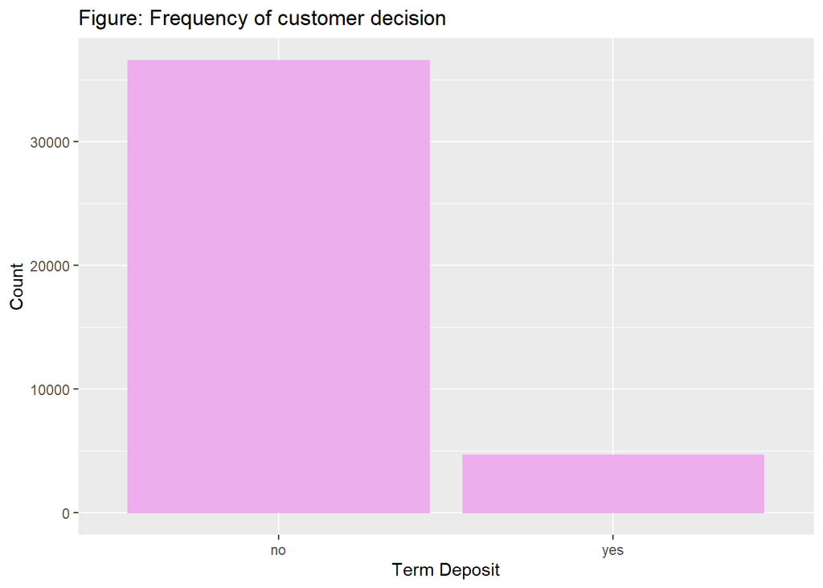

```r
# Compute number of customer decision in the data
count.decision<-aggregate(bank.df$y, by=list(bank.df$y), FUN=count)
names(count.decision)<-c("Term Deposit", "Count")
ggplot(data=count.decision, mapping = aes(x=`Term Deposit`, y=`Count`))+geom_col(color="plum2", fill="plum2") + ggtitle("Figure: Frequency of customer decision")
```

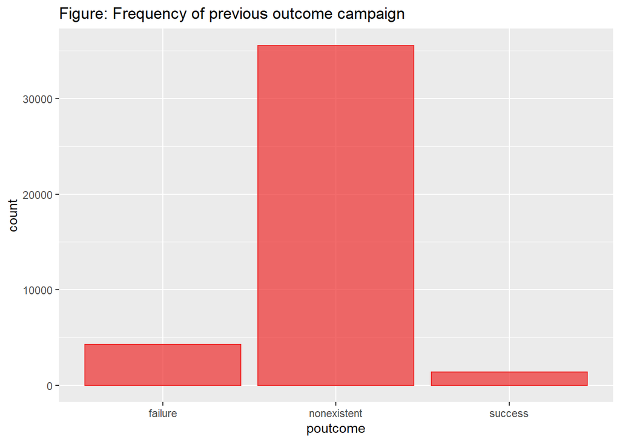

```r
# Number of previous outcome
ggplot(data=bank.df, mapping=aes(x=poutcome))+geom_bar(colour="firebrick2", alpha=0.7, fill="firebrick2") + ggtitle("Figure: Frequency of previous outcome campaign")
```

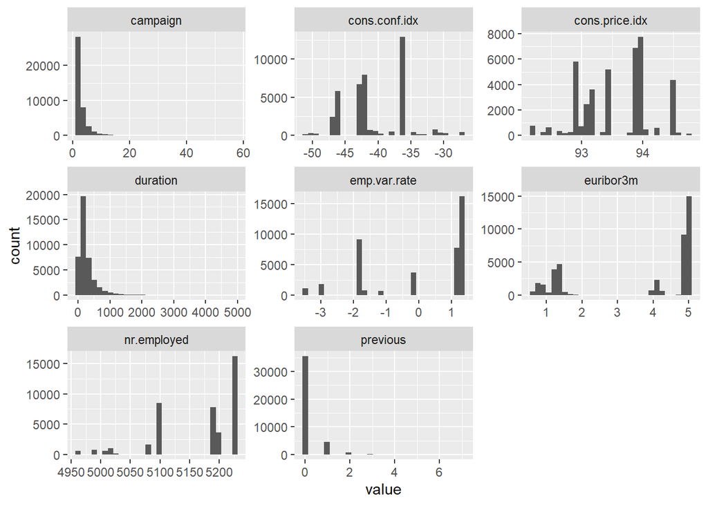

```r
bank.df[,-c(1,13)]%>%keep(is.numeric)%>%gather()%>%ggplot(aes(value))+facet_wrap(~key, scales = "free")+geom_histogram(bins=30)
```

**Understand data by multidimensional visualization**

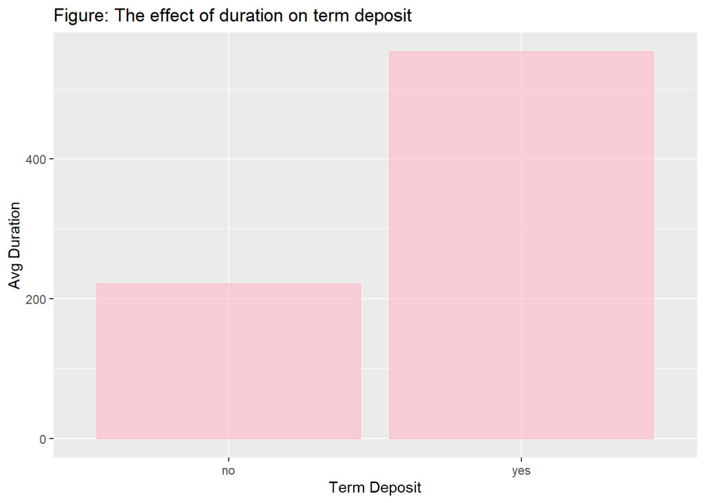

```r
# Compute mean of Duration per Y = Yes, No
data.duration<-aggregate(bank.df$duration, by=list(bank.df$y), FUN=mean)
names(data.duration)<-c("Term Deposit","Avg Duration")
ggplot(data=data.duration, mapping=aes(x=`Term Deposit`, y=`Avg Duration`))+geom_col(color="pink", fill="pink", alpha=0.7) + ggtitle("Figure: The effect of duration on term deposit")
```

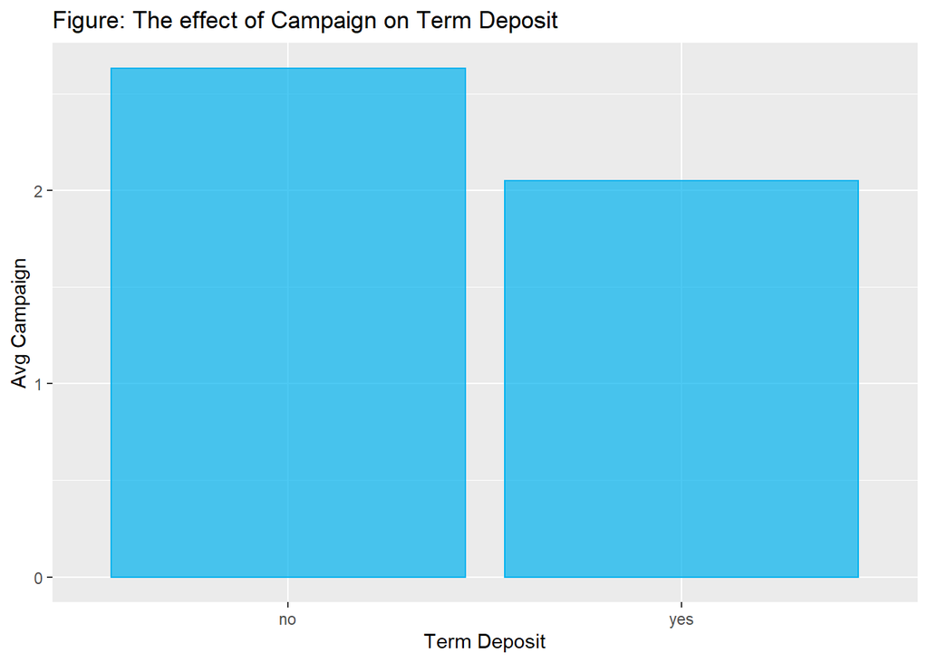

```r
# Compute mean of campaign per Y =Yes, No
data.campaign<-aggregate(bank.df$campaign, by=list(bank.df$y), FUN=mean)
names(data.campaign)<-c("Term Deposit", "Avg Campaign")
ggplot(data=data.campaign, mapping=aes(x=`Term Deposit`, y=`Avg Campaign`)) + geom_col(color="deepskyblue2", fill="deepskyblue2", alpha=0.7) + ggtitle("Figure: The effect of Campaign on Term Deposit")
```

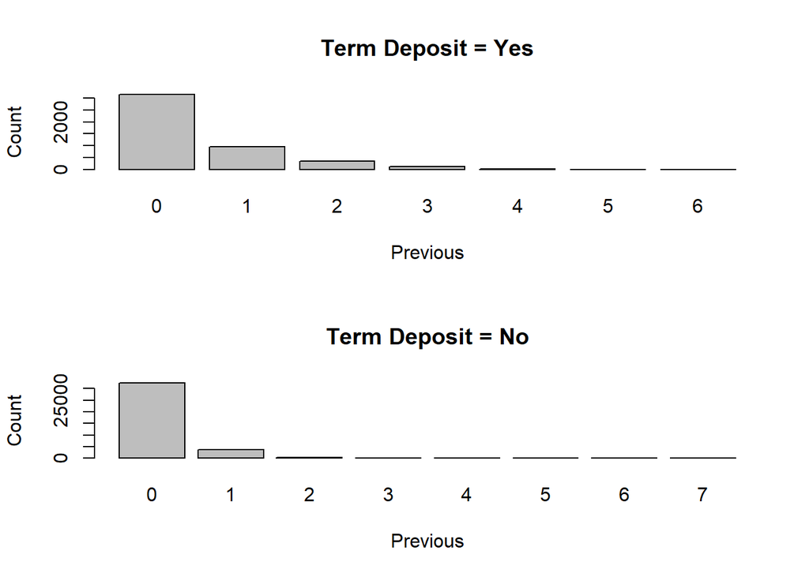

```r
# The effect of number of contacts performed before this campaign and this client by panel plot
data.previous<-aggregate(bank.df$previous, by=list(bank.df$y, bank.df$previous), FUN=count)
names(data.previous)<-c("Term Deposit", "Previous", "Count")
par(mfcol=c(2,1))
barplot(height = data.previous$Count[data.previous$`Term Deposit`=="yes"], names.arg=data.previous$Previous[data.previous$`Term Deposit`=="yes"], xlab="Previous", ylab="Count", main = "Term Deposit = Yes")
barplot(height = data.previous$Count[data.previous$`Term Deposit`=="no"], names.arg=data.previous$Previous[data.previous$`Term Deposit`=="no"], xlab="Previous", ylab="Count", main = "Term Deposit = No")
```

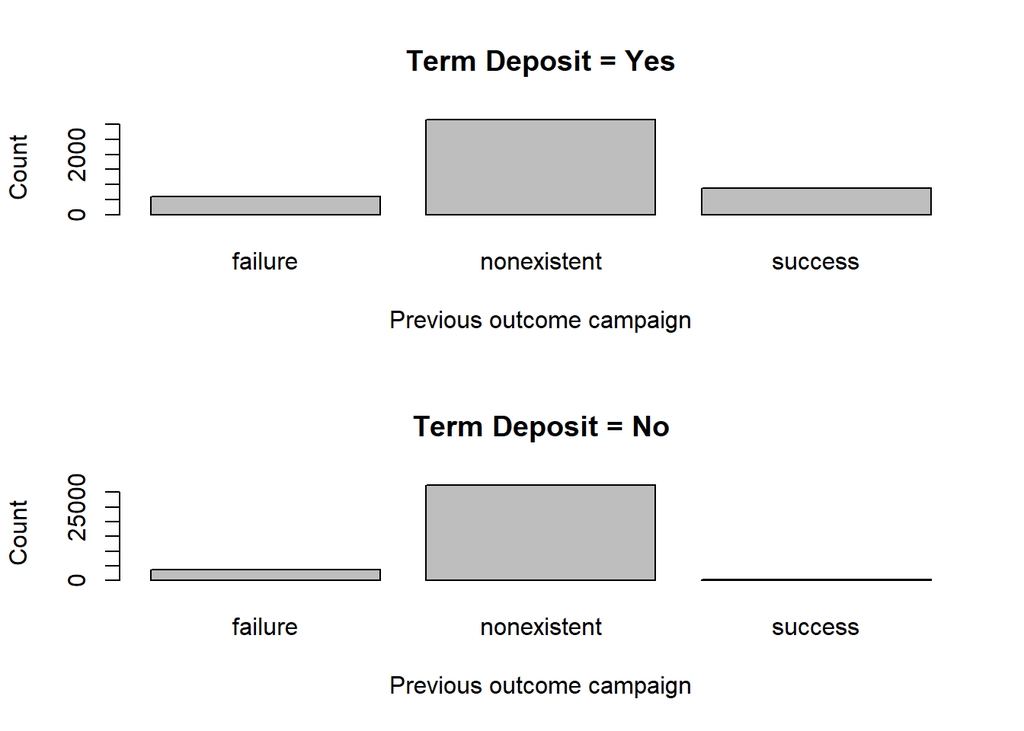

```r
# The effect of previous outcome marketing campaign on term deposit
data.poutcome<-aggregate(bank.df$poutcome, by=list(bank.df$y, bank.df$poutcome), FUN = count)
names(data.poutcome)<-c("Term Deposit", "Previous Marketing Campaign" ,"Count")
par(mfrow=c(2,1))
barplot(height = data.poutcome$Count[data.poutcome$`Term Deposit`=="yes"], names.arg = data.poutcome$`Previous Marketing Campaign`[data.poutcome$`Term Deposit`=="yes"], xlab="Previous outcome campaign", ylab="Count", main="Term Deposit = Yes")
barplot(height = data.poutcome$Count[data.poutcome$`Term Deposit`=="no"], names.arg = data.poutcome$`Previous Marketing Campaign`[data.poutcome$`Term Deposit`=="no"], xlab="Previous outcome campaign", ylab="Count", main="Term Deposit = No")
```

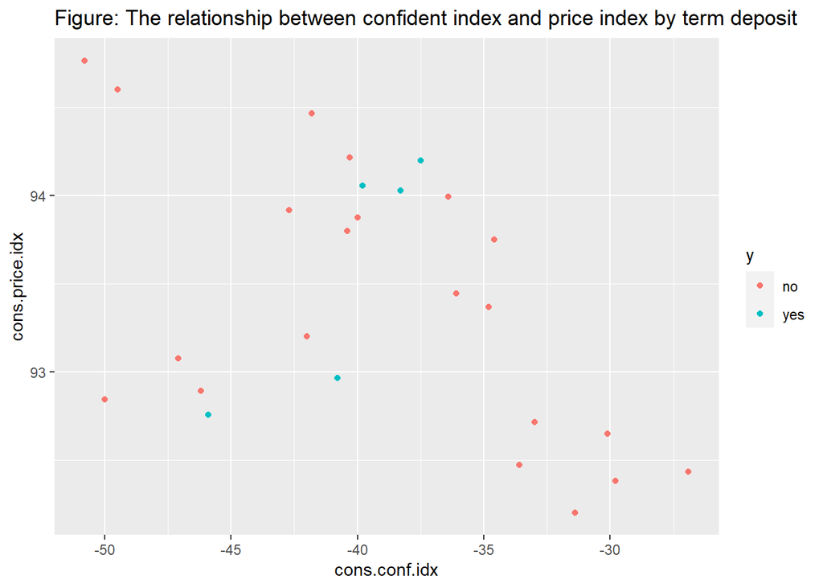

```r
# Scatter plot of confident indext and price index of each customer
ggplot(data=bank.df, aes(y=cons.price.idx,x=cons.conf.idx, color=y)) + geom_point() +ggtitle("Figure: The relationship between confident index and price index by term deposit")
```

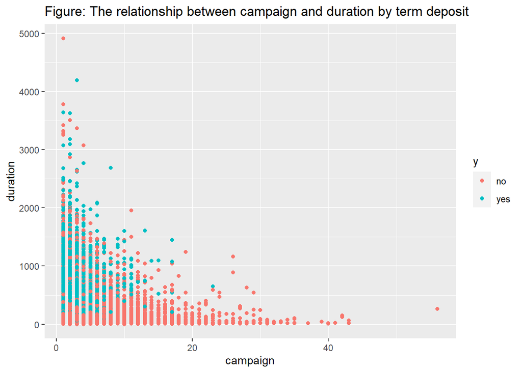

```r
# Scatter plot of duration and campaign of each customer
ggplot(data=bank.df, aes(x=campaign, y=duration, color=y)) + geom_point() + ggtitle ("Figure: The relationship between campaign and duration by term deposit")
```

**Sid-by-Side Boxplot of euribor3m and nr.employed on term deposit**

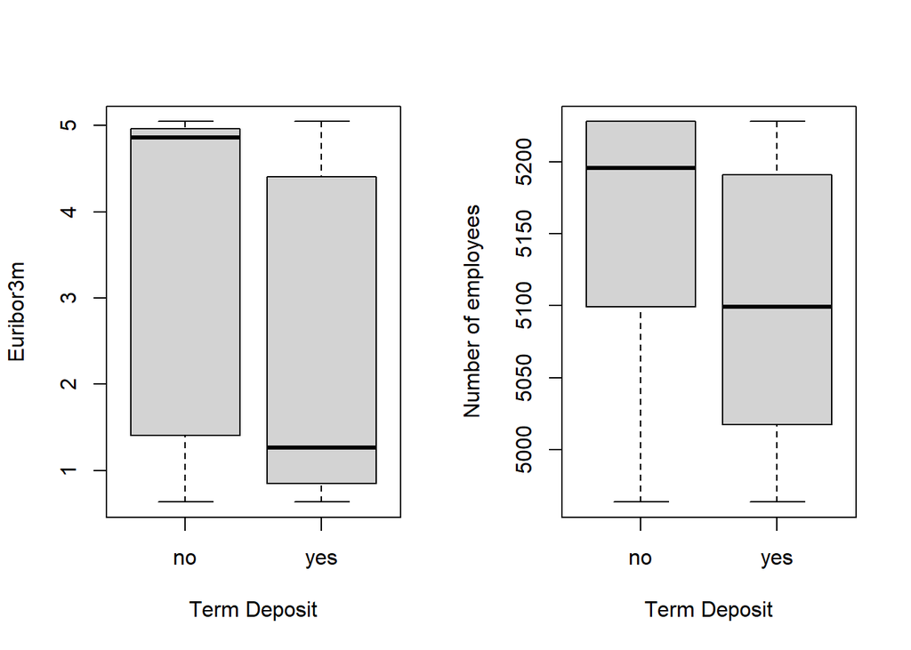

```r
par(mfcol=c(1,2))
boxplot(bank.df$euribor3m~bank.df$y, xlab="Term Deposit", ylab="Euribor3m")
boxplot(bank.df$nr.employed~bank.df$y, xlab = "Term Deposit", ylab="Number of employees")
```

**Heatmap and correlation matrix for correlations**

```r
cor.mat<-round(cor(bank.df[,numerical.variables]),2)
cor.mat%>%kable(caption = "Table: Correlation matrix of numerical variables")%>%kableExtra::kable_styling(bootstrap_options = "striped")
```

Table: Correlation matrix of numerical variables

|  | age | duration | campaign | pdays | previous | emp.var.rate | cons.price.idx | cons.conf.idx | euribor3m | nr.employed |
| --- | --- | --- | --- | --- | --- | --- | --- | --- | --- | --- |
| age | 1.00 | 0.00 | 0.00 | -0.03 | 0.02 | 0.00 | 0.00 | 0.13 | 0.01 | -0.02 |
| duration | 0.00 | 1.00 | -0.07 | -0.05 | 0.02 | -0.03 | 0.01 | -0.01 | -0.03 | -0.04 |
| campaign | 0.00 | -0.07 | 1.00 | 0.05 | -0.08 | 0.15 | 0.13 | -0.01 | 0.14 | 0.14 |
| pdays | -0.03 | -0.05 | 0.05 | 1.00 | -0.59 | 0.27 | 0.08 | -0.09 | 0.30 | 0.37 |
| previous | 0.02 | 0.02 | -0.08 | -0.59 | 1.00 | -0.42 | -0.20 | -0.05 | -0.45 | -0.50 |
| emp.var.rate | 0.00 | -0.03 | 0.15 | 0.27 | -0.42 | 1.00 | 0.78 | 0.20 | 0.97 | 0.91 |
| cons.price.idx | 0.00 | 0.01 | 0.13 | 0.08 | -0.20 | 0.78 | 1.00 | 0.06 | 0.69 | 0.52 |
| cons.conf.idx | 0.13 | -0.01 | -0.01 | -0.09 | -0.05 | 0.20 | 0.06 | 1.00 | 0.28 | 0.10 |
| euribor3m | 0.01 | -0.03 | 0.14 | 0.30 | -0.45 | 0.97 | 0.69 | 0.28 | 1.00 | 0.95 |
| nr.employed | -0.02 | -0.04 | 0.14 | 0.37 | -0.50 | 0.91 | 0.52 | 0.10 | 0.95 | 1.00 |

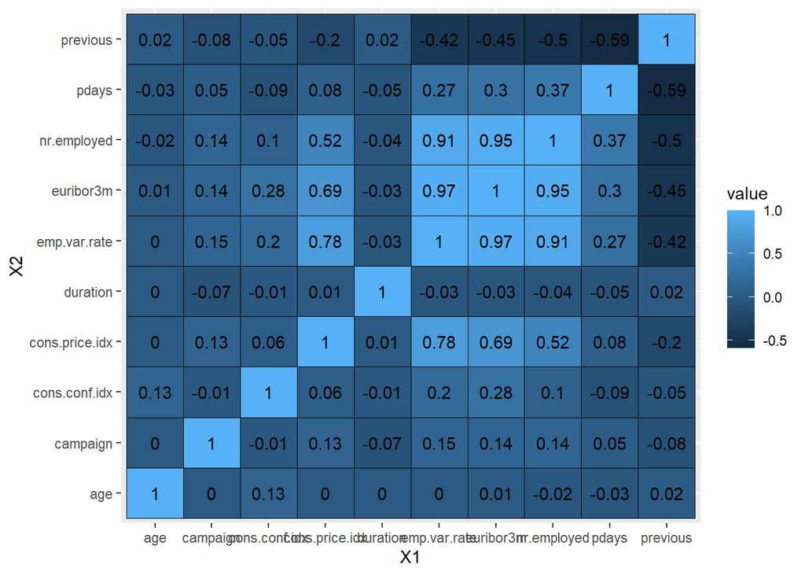

```r
melted.cor.mat<-melt(cor.mat)
names(melted.cor.mat)<-c("X1", "X2", "value")
ggplot(melted.cor.mat, aes(x=X1, y=X2, fill=value)) + geom_tile(col="black") + geom_text(aes(x=X1, y=X2, label=value))
```

### **4. Cleaning data**

**Unknow variable**

```r
# The proportion of Term Deposit with all unknown records
unknown.term<-group_by(bank.df, y)
unknown.term<-summarise(unknown.term,count=n())
unknown.term$count<-as.numeric(unknown.term$count)
unknown.term<-mutate(unknown.term, percent=count/sum(count))
unknown.term%>%kable(caption="Table: The proportion of yes and no with all unknown observations")%>%kableExtra::kable_styling(bootstrap_options = "striped")
```

Table: The proportion of yes and no with all unknown observations

| y | count | percent |
| --- | --- | --- |
| no | 36548 | 0.8873458 |
| yes | 4640 | 0.1126542 |

```r
# The proportion of Term Deposit without unknown observations
bank.df2<-filter(bank.df, job!="unknown", marital!="unknown",education!="unknown", default!="unknown", housing!="unknown")
nonunknown.term<-group_by(bank.df2,y)
nonunknown.term<-summarise(nonunknown.term,count=n())
nonunknown.term$count<-as.numeric(nonunknown.term$count)
nonunknown.term<-mutate(nonunknown.term, percent=count/sum(count))
nonunknown.term%>%kable(caption="Table: The proportion of yes and no with without unknown observations")%>%kableExtra::kable_styling(bootstrap_options = "striped", full_width = FALSE)
```

Table: The proportion of yes and no with without unknown observations

| y | count | percent |
| --- | --- | --- |
| no | 26629 | 0.8734256 |
| yes | 3859 | 0.1265744 |

```r
dim(bank.df2)
```

```
## [1] 30488    21
```

```r
head(bank.df2, 10)%>%kable(caption = "Table: Bank dataset without unknown observations")%>%kableExtra::kable_styling(bootstrap_options = "striped")
```

Table: Bank dataset without unknown observations

| age | job | marital | education | default | housing | loan | contact | month | day_of_week | duration | campaign | pdays | previous | poutcome | emp.var.rate | cons.price.idx | cons.conf.idx | euribor3m | nr.employed | y |
| --- | --- | --- | --- | --- | --- | --- | --- | --- | --- | --- | --- | --- | --- | --- | --- | --- | --- | --- | --- | --- |
| 56 | housemaid | married | basic.4y | no | no | no | telephone | may | mon | 261 | 1 | 999 | 0 | nonexistent | 1.1 | 93.994 | -36.4 | 4.857 | 5191 | no |
| 37 | services | married | high.school | no | yes | no | telephone | may | mon | 226 | 1 | 999 | 0 | nonexistent | 1.1 | 93.994 | -36.4 | 4.857 | 5191 | no |
| 40 | admin. | married | basic.6y | no | no | no | telephone | may | mon | 151 | 1 | 999 | 0 | nonexistent | 1.1 | 93.994 | -36.4 | 4.857 | 5191 | no |
| 56 | services | married | high.school | no | no | yes | telephone | may | mon | 307 | 1 | 999 | 0 | nonexistent | 1.1 | 93.994 | -36.4 | 4.857 | 5191 | no |
| 59 | admin. | married | professional.course | no | no | no | telephone | may | mon | 139 | 1 | 999 | 0 | nonexistent | 1.1 | 93.994 | -36.4 | 4.857 | 5191 | no |
| 24 | technician | single | professional.course | no | yes | no | telephone | may | mon | 380 | 1 | 999 | 0 | nonexistent | 1.1 | 93.994 | -36.4 | 4.857 | 5191 | no |
| 25 | services | single | high.school | no | yes | no | telephone | may | mon | 50 | 1 | 999 | 0 | nonexistent | 1.1 | 93.994 | -36.4 | 4.857 | 5191 | no |
| 25 | services | single | high.school | no | yes | no | telephone | may | mon | 222 | 1 | 999 | 0 | nonexistent | 1.1 | 93.994 | -36.4 | 4.857 | 5191 | no |
| 29 | blue-collar | single | high.school | no | no | yes | telephone | may | mon | 137 | 1 | 999 | 0 | nonexistent | 1.1 | 93.994 | -36.4 | 4.857 | 5191 | no |
| 57 | housemaid | divorced | basic.4y | no | yes | no | telephone | may | mon | 293 | 1 | 999 | 0 | nonexistent | 1.1 | 93.994 | -36.4 | 4.857 | 5191 | no |

**Job variable**

```r
bank.df2$job[bank.df2$job=="entrepreneur"] <- "self-employed"
bank.df2$job[bank.df2$job=="housemaid"] <-"blue-collar"
bank.df2$job[bank.df2$job=="admin."] <-"white-collar"
bank.df2$job[bank.df2$job=="management"] <-"white-collar"
bank.df2$job[bank.df2$job=="services"] <-"white-collar"
bank.df2$job[bank.df2$job=="technician"] <-"white-collar"
bank.df2$job[bank.df2$job=="housemaid"] <-"blue-collar"
bank.df2$job[bank.df2$job=="student"]<- "unemployed"
```

```r
table(bank.df2$job)%>%kable(caption="Table: Checking job variable")%>%kableExtra::kable_styling(bootstrap_options = "striped", full_width = FALSE)
```

Table: Checking job variable

| Var1 | Freq |
| --- | --- |
| blue-collar | 6365 |
| retired | 1216 |
| self-employed | 2181 |
| unemployed | 1348 |
| white-collar | 19378 |

**Education variable**

```r
bank.df2$education[bank.df2$education=="illiterate"]<- "below high-school"
bank.df2$education[bank.df2$education=="basic.4y"]<- "below high-school"
bank.df2$education[bank.df2$education=="basic.6y"]<- "below high-school"
bank.df2$education[bank.df2$education=="basic.9y"]<- "below high-school"
```

```r
table(bank.df2$education)%>%kable(caption= "Table: Checking education variable")%>%kableExtra::kable_styling(bootstrap_options = "striped", full_width = FALSE)
```

Table: Checking education variable

| Var1 | Freq |
| --- | --- |
| below high-school | 8056 |
| high.school | 7699 |
| professional.course | 4321 |
| university.degree | 10412 |

**Month varible**

```r
bank.df2$month<-ifelse(bank.df2$month=="mar", "spring", ifelse(bank.df2$month=="apr"|bank.df2$month=="may"|bank.df2$month=="jun", "summer", ifelse(bank.df2$month=="jul"|bank.df2$month=="aug"|bank.df2$month=="sep", "fall", "winter")))
```

```r
table(bank.df2$month)%>%kable(caption = "Table: Checking month")%>%kableExtra::kable_styling(bootstrap_options = "striped", full_width = FALSE)
```

Table: Checking month

| Var1 | Freq |
| --- | --- |
| fall | 10249 |
| spring | 482 |
| summer | 15462 |
| winter | 4295 |

**pdays variable**

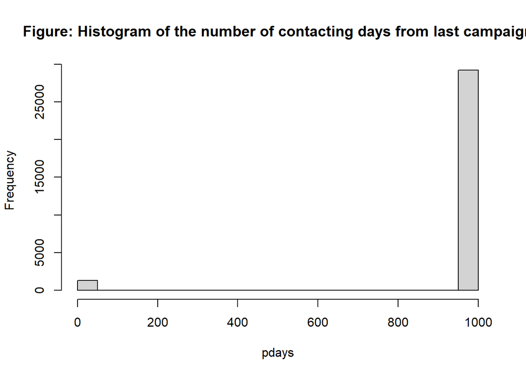

```r
hist(bank.df2$pdays,main = "Figure: Histogram of the number of contacting days from last campaign", xlab="pdays")
```

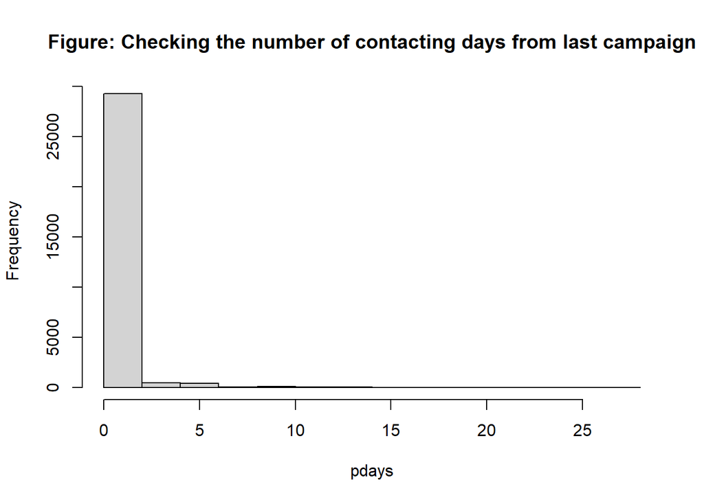

```r
bank.df2$pdays[bank.df2$pdays==999]<- 0
bank.df2$pdays<-as.numeric(bank.df2$pdays)
hist(bank.df2$pdays,main = "Figure: Checking the number of contacting days from last campaign", xlab="pdays")
```

### **5. Data Dimension and varibles selection**

#### **Categorical varibles**

**The effect of job type on Term deposit decision**

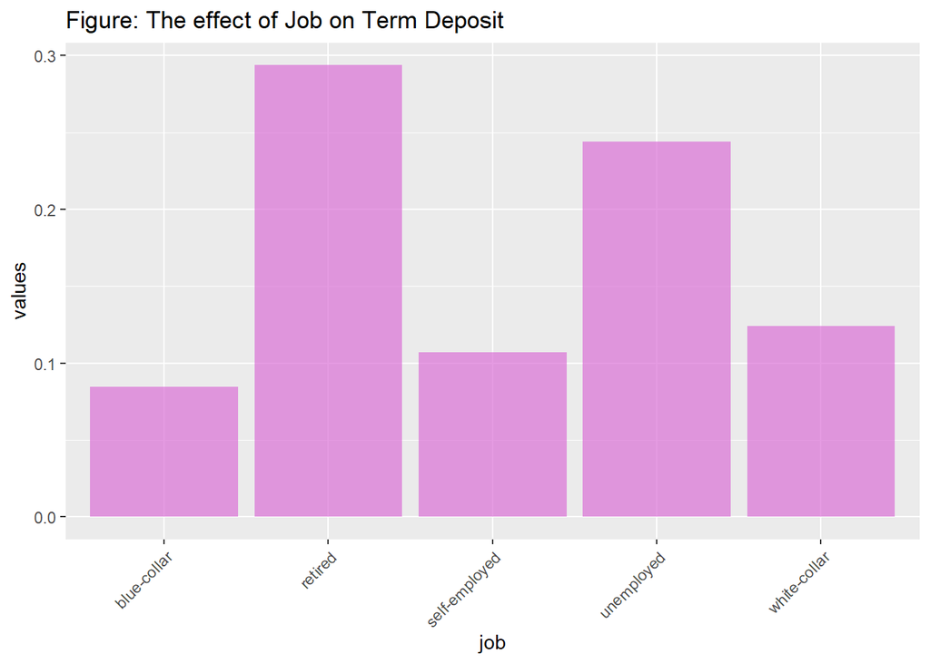

```r
job.agg<-aggregate(bank.df2$y=="yes", by=list(bank.df2$job), mean)
names(job.agg)<-c("job", "values")
ggplot(data = job.agg, mapping = aes(x=job, y=values)) + geom_col(fill="orchid", alpha=0.7) + theme (axis.text.x=element_text(angle = 45, hjust = 1)) + ggtitle("Figure: The effect of Job on Term Deposit")
```

**The effect of marital on Term deposit decision**

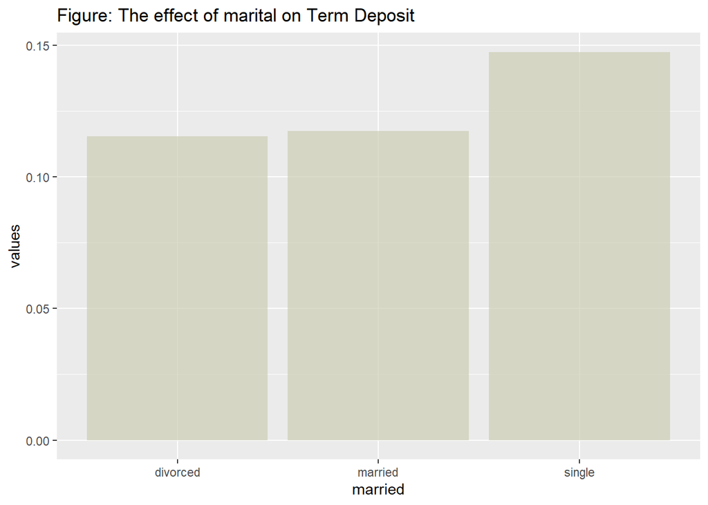

```r
married.agg<-aggregate(bank.df2$y=="yes", by=list(bank.df2$marital), mean)
names(married.agg)<-c("married", "values")
ggplot(data = married.agg, mapping = aes(x=married, y=values)) + geom_col(fill="lightyellow3", alpha=0.7) + ggtitle("Figure: The effect of marital on Term Deposit")
```

**The effect of education on term deposit**

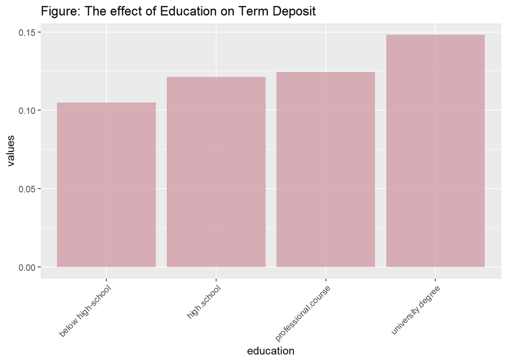

```r
education.agg<-aggregate(bank.df2$y=="yes", by=list(bank.df2$education), mean)
names(education.agg)<-c("education", "values")
ggplot(data = education.agg, mapping = aes(x=education, y=values)) + geom_col(fill="pink3", alpha=0.7) + theme (axis.text.x=element_text(angle = 45, hjust = 1)) + ggtitle("Figure: The effect of Education on Term Deposit")
```

**The effect of default on term deposit**

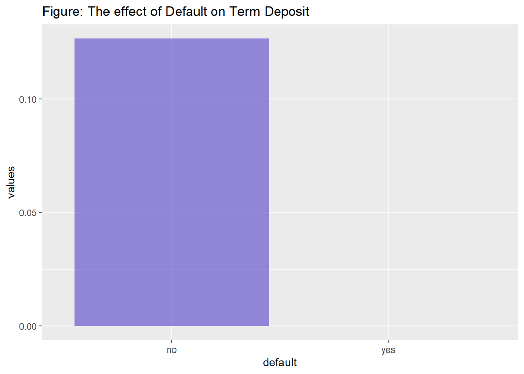

```r
default.agg<-aggregate(bank.df2$y=="yes", by=list(bank.df2$default), mean)
names(default.agg)<-c("default", "values")
ggplot(data = default.agg, mapping = aes(x=default, y=values)) + geom_col(fill="slateblue3", alpha=0.7) + ggtitle("Figure: The effect of Default on Term Deposit")
```

**The effect of housing loan on Term deposit decision**